# RQ1.1: How do model architecture and training environment impact training energy consumption and GPU usage?

Santiago del Rey

## Load and preprocess data

We load the data from the parquet file, filter out the `inception_v3` architecture and the `Desktop Normal User` training environment, and normalize the energy consumption by the total number of images seen during training (converting MJ to J). We also prepare the `gpu_usage` variable.

```r
df <- read_parquet("data/metrics/processed/clean-dl-training-energy-consumption-dataset.gzip") %>%
  filter(architecture != "inception_v3" & `training environment` != "Desktop Normal User") %>%
  mutate(
    energy = (`energy (MJ)` * 1000000) / `total seen images`, # Convert MJ to J and normalize by total seen images
    training_environment = factor(`training environment`, levels = c("Desktop ML Engineer", "Server")),
    architecture = case_match(
      architecture,
      "mobilenet_v2" ~ "Mobilenet V2",
      "nasnet_mobile" ~ "NASNet Mobile",
      "resnet50" ~ "ResNet50",
      "xception" ~ "Xception",
      "vgg16" ~ "VGG16"
    ),
    architecture = factor(architecture, levels = c("Mobilenet V2", "NASNet Mobile", "ResNet50", "Xception", "VGG16")),
    gpu_usage = `gpu usage (%)`
  ) %>%
  select(energy, gpu_usage, architecture, training_environment)
```

```r
# Define a function to filter outliers of a given variable on an input data frame
filter_outliers <- function(df, variable) {
  df %>%
    group_by(architecture, training_environment) %>%
    mutate(
      Q1 = quantile(!!sym(variable), 0.25),
      Q3 = quantile(!!sym(variable), 0.75),
      IQR = Q3 - Q1,
      is_outlier = !!sym(variable) < (Q1 - 1.5 * IQR) | !!sym(variable) > (Q3 + 1.5 * IQR)
    ) %>%
    ungroup() %>%
    filter(!is_outlier) %>%
    select(-Q1, -Q3, -IQR, -is_outlier)
}

filtered_energy_data <- filter_outliers(df, "energy")
# Outlier filtering for gpu_usage (by group)
filtered_gpu_data <- filter_outliers(df, "gpu_usage")

# Set sum-to-zero contrasts in each model call so that Type III tests do not depend on global options
sum_contrasts <- list(architecture = "contr.sum", training_environment = "contr.sum")
```

# Energy Consumption Analysis

## Data summary

```r
filtered_energy_data %>%
  group_by(architecture, training_environment) %>%
  summarise(
    mean_energy = mean(energy, na.rm = TRUE),
    sd_energy = sd(energy, na.rm = TRUE),
    min_energy = min(energy, na.rm = TRUE),
    max_energy = max(energy, na.rm = TRUE),
    n = n()
  )
```

| architecture | training_environment | mean_energy | sd_energy | min_energy | max_energy | n |
| --- | --- | --- | --- | --- | --- | --- |
| Mobilenet V2 | Desktop ML Engineer | 0.0787300 | 0.003528173 | 0.07201469 | 0.08361738 | 30 |
| Mobilenet V2 | Server | 0.1392394 | 0.003513126 | 0.13210180 | 0.14480656 | 30 |
| NASNet Mobile | Desktop ML Engineer | 0.1820120 | 0.003302268 | 0.17479977 | 0.18728370 | 30 |
| NASNet Mobile | Server | 0.3342298 | 0.004326698 | 0.32576285 | 0.34152711 | 19 |
| ResNet50 | Desktop ML Engineer | 0.2101970 | 0.009012883 | 0.19761687 | 0.22458692 | 29 |
| ResNet50 | Server | 0.2747512 | 0.015134816 | 0.25071063 | 0.30448583 | 30 |
| Xception | Desktop ML Engineer | 0.2638586 | 0.003389955 | 0.25757611 | 0.27135801 | 30 |
| Xception | Server | 0.3346210 | 0.002567402 | 0.32903663 | 0.33918218 | 27 |
| VGG16 | Desktop ML Engineer | 0.4120537 | 0.005802632 | 0.40070756 | 0.42163598 | 32 |
| VGG16 | Server | 0.3892791 | 0.006511828 | 0.38179475 | 0.41020854 | 25 |

## Visualize the data

### Histograms of energy consumption

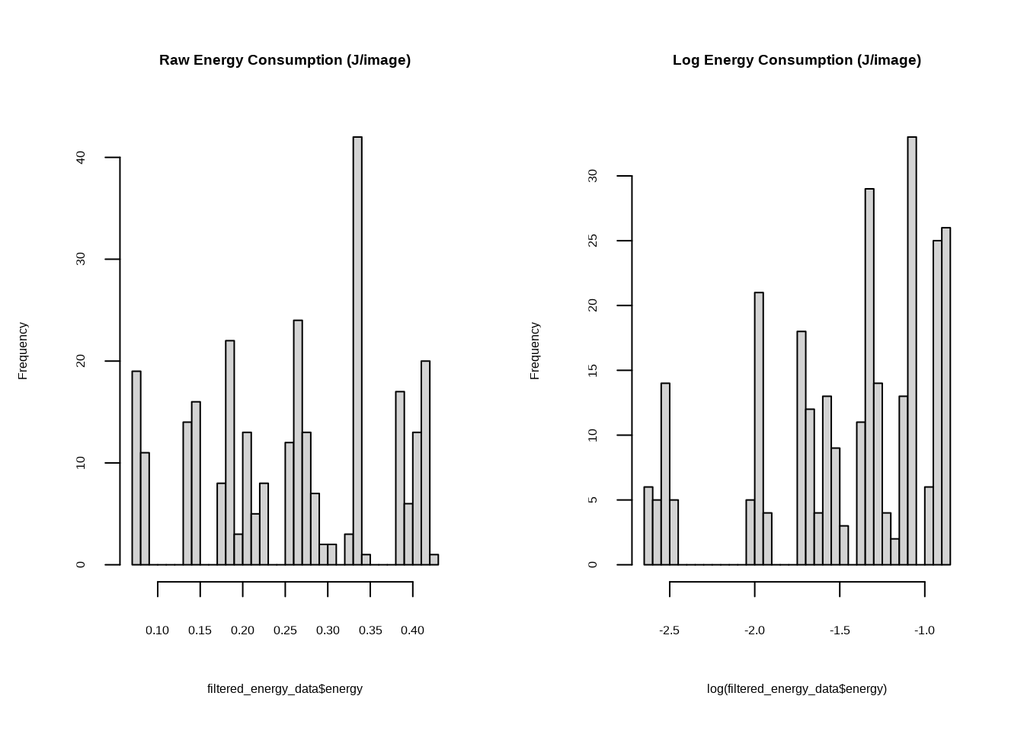

```r
par(mfrow = c(1, 2)) # Set up a 1x2 grid for histograms
hist(filtered_energy_data$energy, main = "Raw Energy Consumption (J/image)", breaks = 30)
hist(log(filtered_energy_data$energy), main = "Log Energy Consumption (J/image)", breaks = 30)
```

### Bar plot of energy consumption by architecture and training environment

```r
median_energy_by_arch_env <- filtered_energy_data %>%
  group_by(architecture, training_environment) %>%
  summarise(median_energy = median(energy, na.rm = TRUE)) %>%
  ungroup()
```

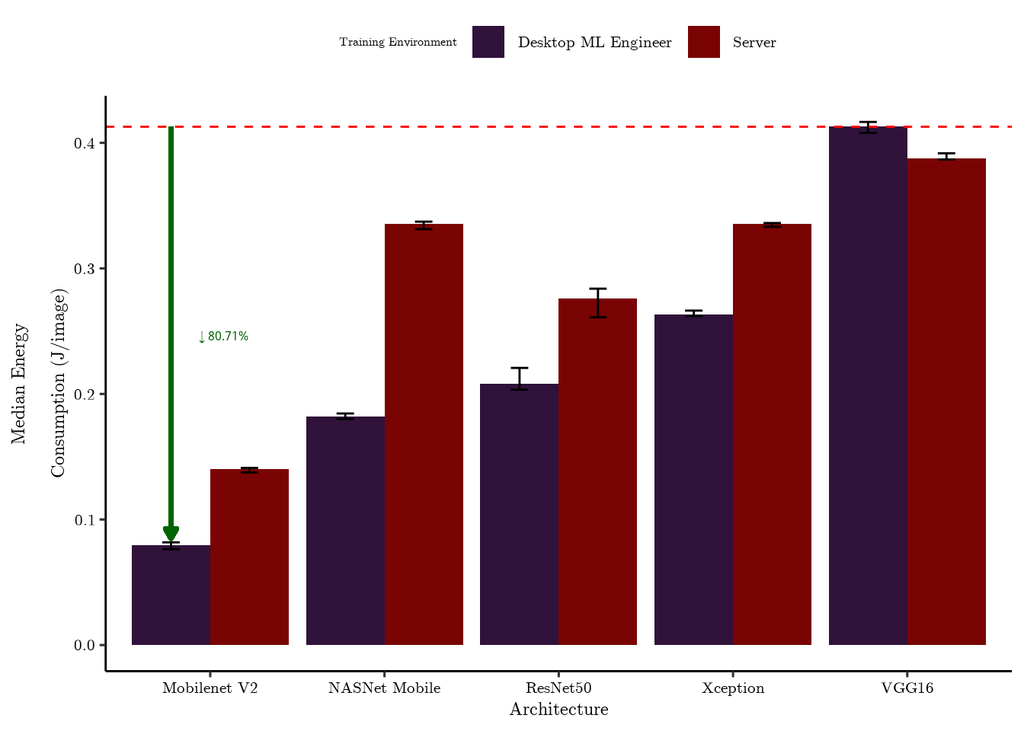

```r
greenest_architecture <- median_energy_by_arch_env %>%
  filter(median_energy == min(median_energy)) %>%
  pull(architecture) %>%
  unique()
greenest_bar_height <- median_energy_by_arch_env %>%
  filter(architecture == greenest_architecture) %>%
  summarise(min_energy = min(median_energy)) %>%
  pull(min_energy)

max_median_energy <- max(median_energy_by_arch_env$median_energy)

dodge_width <- 0.9
env_levels <- levels(factor(filtered_energy_data$training_environment)) # preserves order
target_env <- "Desktop ML Engineer"

env_index <- which(env_levels == target_env)
n_envs <- length(env_levels)
offset <- dodge_width * ((env_index - 0.5) / n_envs - 0.5)

x_base <- as.numeric(factor(greenest_architecture))
x_pos <- x_base + offset

relative_improvement <- (max_median_energy - greenest_bar_height) / max_median_energy * 100
label_text <- paste0("↓ ", formatC(relative_improvement, format = "f", digits = 2), "%")

make_energy_plot <- function(annotation_font_size = 16) {
  annottation_size <- annotation_font_size / ggplot2::.pt # Convert to relative size
  ggplot(filtered_energy_data, aes(x = architecture, y = energy, fill = training_environment)) +
    geom_bar(stat = "summary", fun = "median", position = position_dodge()) +
    # Error bars show the interquartile range
    geom_errorbar(
      stat = "summary",
      fun.data = median_hilow,
      fun.args = list(conf.int = 0.5),
      position = position_dodge(width = 0.9),
      width = 0.2
    ) +
    # Add a horizontal line for the maximum median energy consumption
    geom_hline(
      yintercept = max_median_energy,
      linetype = "dashed", color = "red"
    ) +
    # Add arrow pointing down
    geom_segment(
      aes(
        x = x_pos,
        xend = x_pos,
        y = max_median_energy,
        yend = greenest_bar_height + 0.005,
      ),
      arrow = arrow(length = unit(0.2, "cm"), type = "closed"),
      color = "darkgreen",
      linewidth = 1,
      alpha = 0.7,
      inherit.aes = FALSE
    ) +
    # Add text label
    annotate(
      "text",
      x = x_pos + 0.3, # horizontal offset to the right of the arrow
      y = greenest_bar_height + (max_median_energy - greenest_bar_height) / 2, # vertical midpoint
      label = label_text,
      color = "darkgreen",
      fontface = "bold",
      size = annottation_size
    ) +
    labs(
      x = "Architecture",
      y = "Median Energy\nConsumption (J/image)",
      fill = "Training Environment"
    )
}

make_energy_plot(12)
```

```r
ggsave(make_energy_plot(9) + pub_theme,
  filename = file.path(fig_dir, "energy_by_arch_and_env.pdf"),
  device = cairo_pdf,
  units = "cm",
  width = 13.71, height = 8, dpi = 300
)
```

## Linear Model

Fit a linear model to the energy consumption data, including an interaction term between architecture and training environment.

```r
model_energy <- lm(energy ~ architecture * training_environment, data = filtered_energy_data, contrasts = sum_contrasts)
summary(model_energy)
```

```
##
## Call:
## lm(formula = energy ~ architecture * training_environment, data = filtered_energy_data,
##     contrasts = sum_contrasts)
##
## Residuals:
##        Min         1Q     Median         3Q        Max
## -0.0240405 -0.0030677  0.0002766  0.0031561  0.0297347
##
## Coefficients:
##                                       Estimate Std. Error  t value Pr(>|t|)
## (Intercept)                          0.2618972  0.0004137  633.103  < 2e-16 ***
## architecture1                       -0.1529125  0.0008023 -190.582  < 2e-16 ***
## architecture2                       -0.0037762  0.0008835   -4.274 2.66e-05 ***
## architecture3                       -0.0194231  0.0008074  -24.056  < 2e-16 ***
## architecture4                        0.0373426  0.0008185   45.621  < 2e-16 ***
## training_environment1               -0.0325269  0.0004137  -78.630  < 2e-16 ***
## architecture1:training_environment1  0.0022722  0.0008023    2.832 0.004972 **
## architecture2:training_environment1 -0.0435820  0.0008835  -49.329  < 2e-16 ***
## architecture3:training_environment1  0.0002498  0.0008074    0.309 0.757241
## architecture4:training_environment1 -0.0028543  0.0008185   -3.487 0.000569 ***
## ---
## Signif. codes:  0 '***' 0.001 '**' 0.01 '*' 0.05 '.' 0.1 ' ' 1
##
## Residual standard error: 0.006875 on 272 degrees of freedom
## Multiple R-squared:  0.9959, Adjusted R-squared:  0.9957
## F-statistic:  7277 on 9 and 272 DF,  p-value: < 2.2e-16
```

## Model diagnostics

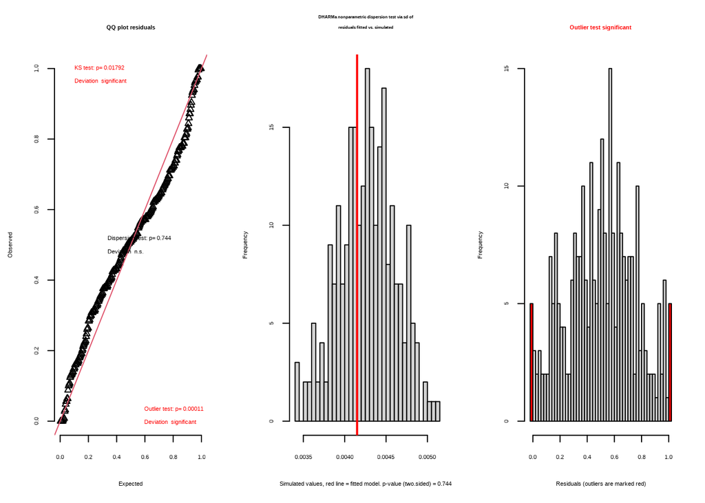

```
## $uniformity
##
##  Asymptotic one-sample Kolmogorov-Smirnov test
##
## data:  simulationOutput$scaledResiduals
## D = 0.091433, p-value = 0.01792
## alternative hypothesis: two-sided
##
##
## $dispersion
##
##  DHARMa nonparametric dispersion test via sd of residuals fitted vs.
##  simulated
##
## data:  simulationOutput
## dispersion = 0.97191, p-value = 0.744
## alternative hypothesis: two.sided
##
##
## $outliers
##
##  DHARMa outlier test based on exact binomial test with approximate
##  expectations
##
## data:  simulationOutput
## outliers at both margin(s) = 10, observations = 282, p-value =
## 0.0001084
## alternative hypothesis: true probability of success is not equal to 0.007968127
## 95 percent confidence interval:
##  0.01713353 0.06424551
## sample estimates:
## frequency of outliers (expected: 0.00796812749003984 )
##                                             0.03546099
```

```r
sim_res_energy <- simulateResiduals(fittedModel = model_energy)
testResiduals(sim_res_energy)
```

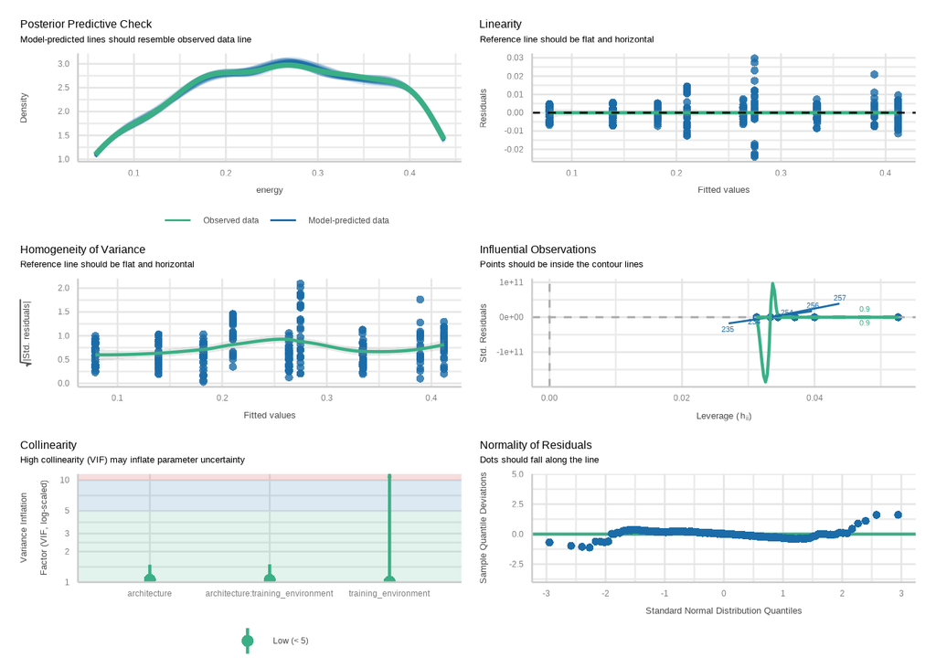

```r
check_model(model_energy)
```

The residual variance differs across cells, so we complement the classical tests with heteroscedasticity-consistent (HC3) tests.

```r
leveneTest(energy ~ architecture * training_environment, data = filtered_energy_data)
```

|  | Df | F value | Pr(>F) |
| --- | --- | --- | --- |
| group | 9 | 14.56559 | 3.229629e-19 |
|  | 272 | NA | NA |

## Significance testing

Type III tests with sum-to-zero contrasts (set in the model call, so the warning `effectsize` gives for Type III tables does not apply). Effect sizes are computed from the Type III sums of squares.

```r
anova_energy <- Anova(model_energy, type = 3)
anova_energy
```

|  | Sum Sq | Df | F value | Pr(>F) |
| --- | --- | --- | --- | --- |
| (Intercept) | 18.94399174 | 1 | 400820.034 | 0.000000e+00 |
| architecture | 2.58498317 | 4 | 13673.373 | 3.834401e-312 |
| training_environment | 0.29221028 | 1 | 6182.632 | 4.491402e-189 |
| architecture:training_environment | 0.19676806 | 4 | 1040.813 | 1.698028e-163 |
| Residuals | 0.01285556 | 272 | NA | NA |

```r
Anova(model_energy, type = 3, white.adjust = "hc3") # robust to unequal variances
```

```
## Coefficient covariances computed by hccm()
```

|  | Df | F | Pr(>F) |
| --- | --- | --- | --- |
| (Intercept) | 1 | 413854.181 | 0.000000e+00 |
| architecture | 4 | 34747.637 | 0.000000e+00 |
| training_environment | 1 | 6383.683 | 6.924986e-191 |
| architecture:training_environment | 4 | 1960.100 | 3.793718e-199 |
| Residuals | 272 | NA | NA |

```r
effectsize::eta_squared(anova_energy, partial = FALSE, verbose = FALSE) # eta-squared
```

| Parameter | Eta2 | CI | CI_low | CI_high |
| --- | --- | --- | --- | --- |
| architecture | 0.83742674 | 0.95 | 0.81184830 | 1 |
| training_environment | 0.09466394 | 0.95 | 0.04647294 | 1 |
| architecture:training_environment | 0.06374465 | 0.95 | 0.01642092 | 1 |

```r
effectsize::eta_squared(anova_energy, partial = TRUE, verbose = FALSE) # partial eta-squared
```

| Parameter | Eta2_partial | CI | CI_low | CI_high |
| --- | --- | --- | --- | --- |
| architecture | 0.9950514 | 0.95 | 0.9942673 | 1 |
| training_environment | 0.9578597 | 0.95 | 0.9512008 | 1 |
| architecture:training_environment | 0.9386731 | 0.95 | 0.9289450 | 1 |

## Post hoc tests

```r
emm_energy <- emmeans(model_energy, ~ architecture * training_environment, type = "response")
pair_comparison <- pairs(emm_energy, type = "response")

# To view results:
summary(emm_energy)
```

|  | architecture | training_environment | emmean | SE | df | lower.CL | upper.CL |
| --- | --- | --- | --- | --- | --- | --- | --- |
| 1 | Mobilenet V2 | Desktop ML Engineer | 0.0787300 | 0.001255164 | 272 | 0.07625893 | 0.08120107 |
| 2 | NASNet Mobile | Desktop ML Engineer | 0.1820120 | 0.001255164 | 272 | 0.17954098 | 0.18448312 |
| 3 | ResNet50 | Desktop ML Engineer | 0.2101970 | 0.001276621 | 272 | 0.20768366 | 0.21271029 |
| 4 | Xception | Desktop ML Engineer | 0.2638586 | 0.001255164 | 272 | 0.26138758 | 0.26632972 |
| 5 | VGG16 | Desktop ML Engineer | 0.4120537 | 0.001215307 | 272 | 0.40966113 | 0.41444634 |
| 6 | Mobilenet V2 | Server | 0.1392394 | 0.001255164 | 272 | 0.13676833 | 0.14171047 |
| 7 | NASNet Mobile | Server | 0.3342298 | 0.001577191 | 272 | 0.33112479 | 0.33733490 |
| 8 | ResNet50 | Server | 0.2747512 | 0.001255164 | 272 | 0.27228008 | 0.27722222 |
| 9 | Xception | Server | 0.3346210 | 0.001323059 | 272 | 0.33201625 | 0.33722572 |
| 10 | VGG16 | Server | 0.3892791 | 0.001374963 | 272 | 0.38657222 | 0.39198607 |

```r
summary(pair_comparison)
```

|  | contrast | estimate | SE | df | t.ratio | p.value |
| --- | --- | --- | --- | --- | --- | --- |
| 1 | Mobilenet V2 Desktop ML Engineer - NASNet Mobile Desktop ML Engineer | -0.1032820528 | 0.001775070 | 272 | -58.1847876 | 3.917977e-13 |
| 2 | Mobilenet V2 Desktop ML Engineer - ResNet50 Desktop ML Engineer | -0.1314669821 | 0.001790307 | 272 | -73.4326627 | 3.917977e-13 |
| 3 | Mobilenet V2 Desktop ML Engineer - Xception Desktop ML Engineer | -0.1851286515 | 0.001775070 | 272 | -104.2937371 | 3.917977e-13 |
| 4 | Mobilenet V2 Desktop ML Engineer - VGG16 Desktop ML Engineer | -0.3333237367 | 0.001747114 | 272 | -190.7853292 | 3.917977e-13 |
| 5 | Mobilenet V2 Desktop ML Engineer - Mobilenet V2 Server | -0.0605094043 | 0.001775070 | 272 | -34.0884669 | 3.917977e-13 |
| 6 | Mobilenet V2 Desktop ML Engineer - NASNet Mobile Server | -0.2554998491 | 0.002015680 | 272 | -126.7561378 | 3.917977e-13 |
| 7 | Mobilenet V2 Desktop ML Engineer - ResNet50 Server | -0.1960211572 | 0.001775070 | 272 | -110.4301191 | 3.917977e-13 |
| 8 | Mobilenet V2 Desktop ML Engineer - Xception Server | -0.2558909900 | 0.001823711 | 272 | -140.3133644 | 3.917977e-13 |
| 9 | Mobilenet V2 Desktop ML Engineer - VGG16 Server | -0.3105491487 | 0.001861709 | 272 | -166.8086595 | 3.917977e-13 |
| 10 | NASNet Mobile Desktop ML Engineer - ResNet50 Desktop ML Engineer | -0.0281849293 | 0.001790307 | 272 | -15.7430738 | 3.917977e-13 |

[output cut: 35 more lines]

Below we show the non-significant pairwise comparisons

```r
pair_comparison_df <- as.data.frame(pair_comparison)
pair_comparison_df %>%
  filter(p.value > 0.05) %>%
  select(contrast, estimate, SE, df, t.ratio, p.value)
```

| contrast | estimate | SE | df | t.ratio | p.value |
| --- | --- | --- | --- | --- | --- |
| NASNet Mobile Server - Xception Server | -0.0003911409 | 0.002058644 | 272 | -0.1899993 | 1 |

Plot the interaction effects

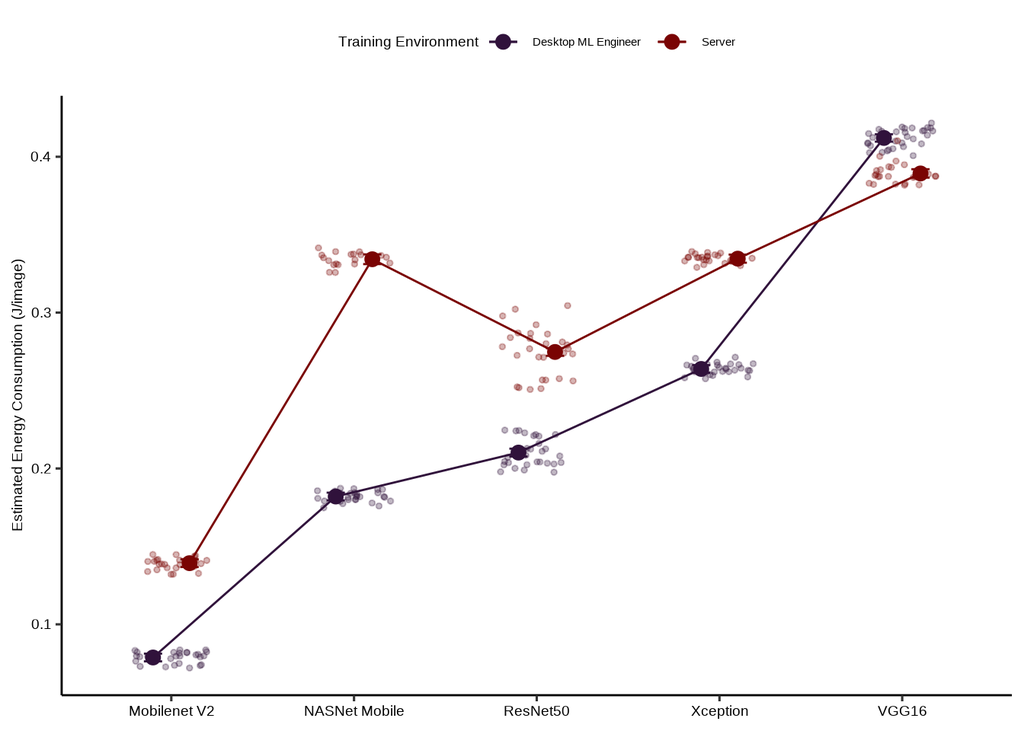

```r
emm_energy_df <- as.data.frame(emm_energy)
emm_df <- emm_energy_df %>%
  mutate(
    energy_estimate = emmean,
    lower_CI = lower.CL,
    upper_CI = upper.CL
  )

# Set the desired order for the x axis
emm_df$architecture <- factor(emm_df$architecture, levels = c("Mobilenet V2", "NASNet Mobile", "ResNet50", "Xception", "VGG16"))

ggplot() +
  # Raw data jittered
  geom_jitter(
    data = filtered_energy_data,
    aes(x = architecture, y = energy, color = training_environment),
    width = 0.2, alpha = 0.3, size = 1
  ) +
  # Estimated points
  geom_point(
    data = emm_df,
    aes(x = architecture, y = energy_estimate, color = training_environment, group = training_environment),
    size = 3, position = position_dodge(width = 0.4)
  ) +
  # Lines connecting estimated points
  geom_line(
    data = emm_df,
    aes(x = architecture, y = energy_estimate, color = training_environment, group = training_environment),
    position = position_dodge(width = 0.4)
  ) +
  # Error bars
  geom_errorbar(
    data = emm_df,
    aes(x = architecture, ymin = lower_CI, ymax = upper_CI, color = training_environment, group = training_environment),
    width = 0.2, position = position_dodge(width = 0.4)
  ) +
  labs(
    title = NULL,
    x = NULL,
    y = "Estimated Energy Consumption (J/image)",
    color = "Training Environment"
  ) +
  theme_pubr() +
  theme(text = element_text(size = 14))
```

## Sensitivity analysis: residual-based trimming

Earlier versions of this analysis removed the observations whose DHARMa scaled residuals fell outside the 2.5%–97.5% quantiles. This rule always removes about 5% of the data, so we only report it as a sensitivity check.

```r
trim_by_scaled_residuals <- function(model, data) {
  scaled_res <- simulateResiduals(fittedModel = model)$scaledResiduals
  outlier_index <- which(scaled_res < quantile(scaled_res, 0.025) | scaled_res > quantile(scaled_res, 0.975))
  list(removed = data[outlier_index, ], kept = if (length(outlier_index) > 0) data[-outlier_index, ] else data)
}

trimmed_energy <- trim_by_scaled_residuals(model_energy, filtered_energy_data)
trimmed_energy$removed %>% count(architecture, training_environment)
```

| architecture | training_environment | n |
| --- | --- | --- |
| ResNet50 | Desktop ML Engineer | 1 |
| ResNet50 | Server | 13 |
| VGG16 | Server | 1 |

```r
model_energy_trimmed <- lm(energy ~ architecture * training_environment, data = trimmed_energy$kept, contrasts = sum_contrasts)
anova_energy_trimmed <- Anova(model_energy_trimmed, type = 3)
anova_energy_trimmed
```

|  | Sum Sq | Df | F value | Pr(>F) |
| --- | --- | --- | --- | --- |
| (Intercept) | 17.591439671 | 1 | 759368.922 | 0.000000e+00 |
| architecture | 2.545793630 | 4 | 27473.541 | 0.000000e+00 |
| training_environment | 0.275719273 | 1 | 11901.962 | 2.940083e-217 |
| architecture:training_environment | 0.196791186 | 4 | 2123.719 | 1.643730e-195 |
| Residuals | 0.005953628 | 257 | NA | NA |

```r
effectsize::eta_squared(anova_energy_trimmed, partial = FALSE, verbose = FALSE)
```

| Parameter | Eta2 | CI | CI_low | CI_high |
| --- | --- | --- | --- | --- |
| architecture | 0.84179123 | 0.95 | 0.81607218 | 1 |
| training_environment | 0.09116924 | 0.95 | 0.04273300 | 1 |
| architecture:training_environment | 0.06507090 | 0.95 | 0.01595375 | 1 |

# GPU Usage Analysis

## Data summary

```r
filtered_gpu_data %>%
  group_by(architecture, training_environment) %>%
  summarise(
    mean_gpu_usage = mean(gpu_usage, na.rm = TRUE),
    sd_gpu_usage = sd(gpu_usage, na.rm = TRUE),
    min_gpu_usage = min(gpu_usage, na.rm = TRUE),
    max_gpu_usage = max(gpu_usage, na.rm = TRUE),
    n = n()
  )
```

| architecture | training_environment | mean_gpu_usage | sd_gpu_usage | min_gpu_usage | max_gpu_usage | n |
| --- | --- | --- | --- | --- | --- | --- |
| Mobilenet V2 | Desktop ML Engineer | 56.14850 | 1.7545563 | 52.51105 | 60.34446 | 30 |
| Mobilenet V2 | Server | 22.69289 | 0.5556347 | 21.47188 | 23.48388 | 29 |
| NASNet Mobile | Desktop ML Engineer | 77.39325 | 1.0720708 | 75.73429 | 79.59898 | 30 |
| NASNet Mobile | Server | 42.13204 | 0.5885176 | 41.07506 | 43.11152 | 18 |
| ResNet50 | Desktop ML Engineer | 90.08626 | 0.8116114 | 88.72971 | 91.49827 | 30 |
| ResNet50 | Server | 78.39781 | 1.2022286 | 76.47336 | 80.55567 | 25 |
| Xception | Desktop ML Engineer | 92.92643 | 0.2534629 | 92.50332 | 93.53525 | 30 |
| Xception | Server | 59.62424 | 0.5083171 | 58.62143 | 60.35210 | 30 |
| VGG16 | Desktop ML Engineer | 95.65935 | 0.1247506 | 95.38018 | 95.85964 | 30 |
| VGG16 | Server | 90.03565 | 0.3365034 | 89.52644 | 90.75999 | 25 |

## Visualize the data

### Histograms of GPU usage

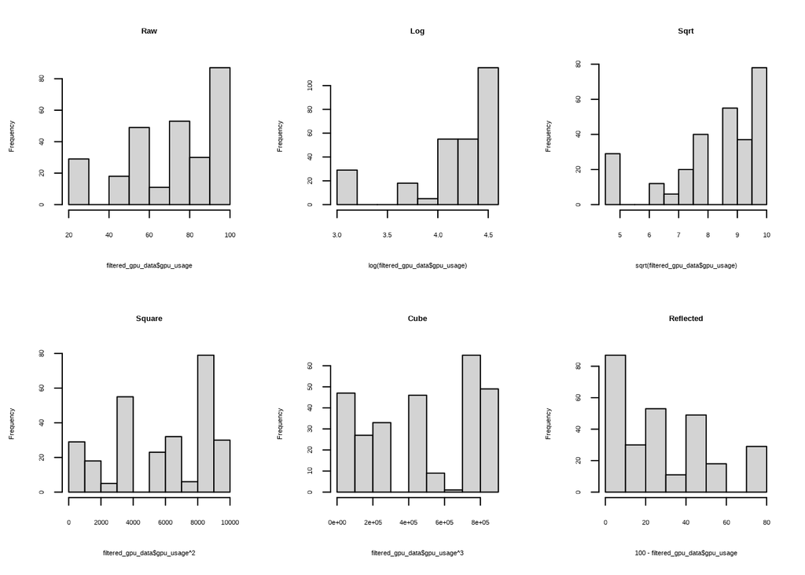

```r
par(mfrow = c(2, 3)) # Set up a 2x3 grid for histograms
hist(filtered_gpu_data$gpu_usage, main = "Raw")
hist(log(filtered_gpu_data$gpu_usage), main = "Log")
hist(sqrt(filtered_gpu_data$gpu_usage), main = "Sqrt")
hist(filtered_gpu_data$gpu_usage^2, main = "Square")
hist(filtered_gpu_data$gpu_usage^3, main = "Cube")
hist(100 - filtered_gpu_data$gpu_usage, main = "Reflected")
```

### Bar plot of GPU usage by architecture and training environment

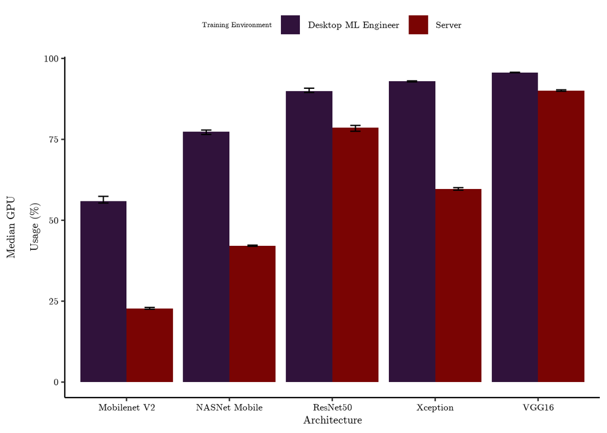

```r
gpu_barplot <- ggplot(filtered_gpu_data, aes(x = architecture, y = gpu_usage, fill = training_environment)) +
  geom_bar(stat = "summary", fun = "median", position = position_dodge()) +
  # Error bars show the interquartile range
  geom_errorbar(
    stat = "summary",
    fun.data = median_hilow,
    fun.args = list(conf.int = 0.5),
    position = position_dodge(width = 0.9),
    width = 0.2
  ) +
  labs(
    x = "Architecture",
    y = "Median GPU\nUsage (%)",
    fill = "Training Environment"
  )

gpu_barplot
```

```r
ggsave(gpu_barplot + pub_theme,
  filename = file.path(fig_dir, "gpu_usage_barplot.pdf"),
  device = cairo_pdf,
  units = "cm",
  width = 13.71, height = 8, dpi = 300
)
```

## Linear Model

```r
max_val <- 100
filtered_gpu_data$gpu_usage_reflected <- sqrt(max_val - filtered_gpu_data$gpu_usage + 1)

model_gpu <- lm(gpu_usage_reflected ~ architecture * training_environment, data = filtered_gpu_data, contrasts = sum_contrasts)
summary(model_gpu)
```

```
##
## Call:
## lm(formula = gpu_usage_reflected ~ architecture * training_environment,
##     data = filtered_gpu_data, contrasts = sum_contrasts)
##
## Residuals:
##      Min       1Q   Median       3Q      Max
## -0.31971 -0.03347  0.00242  0.04529  0.26752
##
## Coefficients:
##                                      Estimate Std. Error  t value Pr(>|t|)
## (Intercept)                          5.102382   0.005168  987.340   <2e-16 ***
## architecture1                        2.670094   0.010006  266.847   <2e-16 ***
## architecture2                        1.162570   0.011088  104.853   <2e-16 ***
## architecture3                       -1.075424   0.010300 -104.408   <2e-16 ***
## architecture4                       -0.465710   0.009944  -46.835   <2e-16 ***
## training_environment1               -1.101067   0.005168 -213.063   <2e-16 ***
## architecture1:training_environment1  0.024467   0.010006    2.445   0.0151 *
## architecture2:training_environment1 -0.306436   0.011088  -27.638   <2e-16 ***
## architecture3:training_environment1  0.375464   0.010300   36.452   <2e-16 ***
## architecture4:training_environment1 -0.694543   0.009944  -69.847   <2e-16 ***
## ---
## Signif. codes:  0 '***' 0.001 '**' 0.01 '*' 0.05 '.' 0.1 ' ' 1
##
## Residual standard error: 0.08495 on 267 degrees of freedom
## Multiple R-squared:  0.9984, Adjusted R-squared:  0.9984
## F-statistic: 1.882e+04 on 9 and 267 DF,  p-value: < 2.2e-16
```

## Model diagnostics

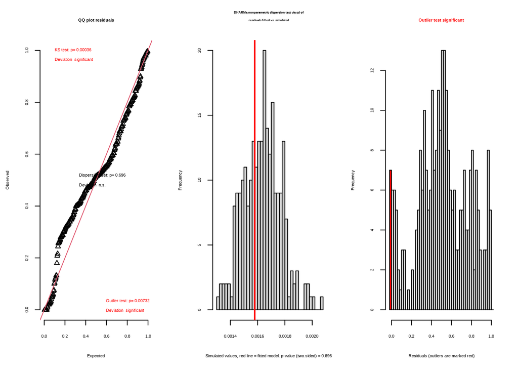

```
## $uniformity
##
##  Asymptotic one-sample Kolmogorov-Smirnov test
##
## data:  simulationOutput$scaledResiduals
## D = 0.12477, p-value = 0.0003596
## alternative hypothesis: two-sided
##
##
## $dispersion
##
##  DHARMa nonparametric dispersion test via sd of residuals fitted vs.
##  simulated
##
## data:  simulationOutput
## dispersion = 0.966, p-value = 0.696
## alternative hypothesis: two.sided
##
##
## $outliers
##
##  DHARMa outlier test based on exact binomial test with approximate
##  expectations
##
## data:  simulationOutput
## outliers at both margin(s) = 7, observations = 277, p-value = 0.007322
## alternative hypothesis: true probability of success is not equal to 0.007968127
## 95 percent confidence interval:
##  0.01021919 0.05137200
## sample estimates:
## frequency of outliers (expected: 0.00796812749003984 )
##                                             0.02527076
```

```r
sim_res_gpu <- simulateResiduals(fittedModel = model_gpu)
testResiduals(sim_res_gpu)
```

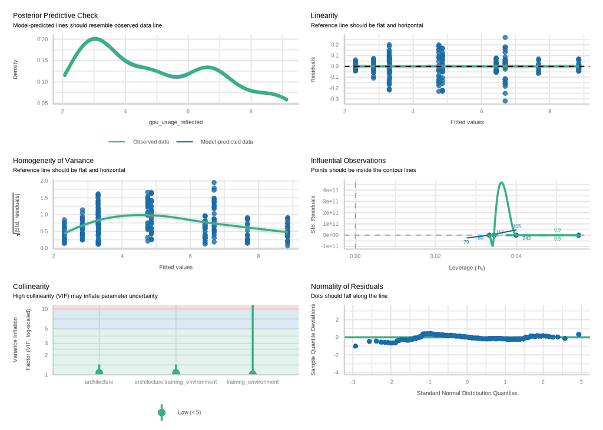

```r
check_model(model_gpu)
```

```r
leveneTest(gpu_usage_reflected ~ architecture * training_environment, data = filtered_gpu_data)
```

|  | Df | F value | Pr(>F) |
| --- | --- | --- | --- |
| group | 9 | 12.07653 | 5.513923e-16 |
|  | 267 | NA | NA |

## Significance testing

Type III tests with sum-to-zero contrasts (set in the model call, so the warning `effectsize` gives for Type III tables does not apply). Effect sizes are computed from the Type III sums of squares.

```r
anova_gpu <- Anova(model_gpu, type = 3)
anova_gpu
```

|  | Sum Sq | Df | F value | Pr(>F) |
| --- | --- | --- | --- | --- |
| (Intercept) | 7035.569573 | 1 | 974841.114 | 0.000000e+00 |
| architecture | 843.844168 | 4 | 29230.540 | 0.000000e+00 |
| training_environment | 327.627907 | 1 | 45395.778 | 3.777672e-300 |
| architecture:training_environment | 60.596739 | 4 | 2099.055 | 2.367490e-200 |
| Residuals | 1.926978 | 267 | NA | NA |

```r
Anova(model_gpu, type = 3, white.adjust = "hc3") # robust to unequal variances
```

```
## Coefficient covariances computed by hccm()
```

|  | Df | F | Pr(>F) |
| --- | --- | --- | --- |
| (Intercept) | 1 | 1003486.053 | 0.000000e+00 |
| architecture | 4 | 44231.816 | 0.000000e+00 |
| training_environment | 1 | 46729.697 | 8.086669e-302 |
| architecture:training_environment | 4 | 6847.775 | 1.203679e-267 |
| Residuals | 267 | NA | NA |

```r
effectsize::eta_squared(anova_gpu, partial = FALSE, verbose = FALSE) # eta-squared
```

| Parameter | Eta2 | CI | CI_low | CI_high |
| --- | --- | --- | --- | --- |
| architecture | 0.68383067 | 0.95 | 0.635483363 | 1 |
| training_environment | 0.26550164 | 0.95 | 0.194466487 | 1 |
| architecture:training_environment | 0.04910611 | 0.95 | 0.007215374 | 1 |

```r
effectsize::eta_squared(anova_gpu, partial = TRUE, verbose = FALSE) # partial eta-squared
```

| Parameter | Eta2_partial | CI | CI_low | CI_high |
| --- | --- | --- | --- | --- |
| architecture | 0.9977216 | 0.95 | 0.9973569 | 1 |
| training_environment | 0.9941528 | 0.95 | 0.9932171 | 1 |
| architecture:training_environment | 0.9691801 | 0.95 | 0.9642404 | 1 |

## Sensitivity analysis: residual-based trimming

```r
trimmed_gpu <- trim_by_scaled_residuals(model_gpu, filtered_gpu_data)
trimmed_gpu$removed %>% count(architecture, training_environment)
```

| architecture | training_environment | n |
| --- | --- | --- |
| Mobilenet V2 | Desktop ML Engineer | 4 |
| NASNet Mobile | Desktop ML Engineer | 3 |
| ResNet50 | Desktop ML Engineer | 2 |
| ResNet50 | Server | 3 |

```r
model_gpu_trimmed <- lm(gpu_usage_reflected ~ architecture * training_environment, data = trimmed_gpu$kept, contrasts = sum_contrasts)
anova_gpu_trimmed <- Anova(model_gpu_trimmed, type = 3)
anova_gpu_trimmed
```

|  | Sum Sq | Df | F value | Pr(>F) |
| --- | --- | --- | --- | --- |
| (Intercept) | 6738.689069 | 1 | 1339602.250 | 0.000000e+00 |
| architecture | 807.786435 | 4 | 40145.513 | 0.000000e+00 |
| training_environment | 311.417479 | 1 | 61907.524 | 2.280873e-306 |
| architecture:training_environment | 59.484103 | 4 | 2956.251 | 2.951357e-212 |
| Residuals | 1.282743 | 255 | NA | NA |

```r
effectsize::eta_squared(anova_gpu_trimmed, partial = FALSE, verbose = FALSE)
```

| Parameter | Eta2 | CI | CI_low | CI_high |
| --- | --- | --- | --- | --- |
| architecture | 0.68458174 | 0.95 | 0.635064141 | 1 |
| training_environment | 0.26391966 | 0.95 | 0.191323334 | 1 |
| architecture:training_environment | 0.05041151 | 0.95 | 0.007040584 | 1 |

## Post hoc tests

```r
emm_gpu <- emmeans(model_gpu, ~ architecture * training_environment)

# back-transform estimated means
emm_gpu_df <- as.data.frame(emm_gpu)
emm_gpu_df <- emm_gpu_df %>%
  mutate(
    gpu_estimate = max_val - emmean^2 + 1,
    lower_CI = max_val - (emmean + SE * qt(0.975, df))^2 + 1,
    upper_CI = max_val - (emmean - SE * qt(0.975, df))^2 + 1
  )

emm_gpu_df
```

|  | architecture | training_environment | emmean | SE | df | lower.CL | upper.CL | gpu_estimate | lower_CI | upper_CI |
| --- | --- | --- | --- | --- | --- | --- | --- | --- | --- | --- |
| 1 | Mobilenet V2 | Desktop ML Engineer | 6.695876 | 0.01551037 | 267 | 6.665338 | 6.726414 | 56.16525 | 55.75536 | 56.57327 |
| 2 | NASNet Mobile | Desktop ML Engineer | 4.857450 | 0.01551037 | 267 | 4.826912 | 4.887988 | 77.40518 | 77.10757 | 77.70092 |
| 3 | ResNet50 | Desktop ML Engineer | 3.301355 | 0.01551037 | 267 | 3.270817 | 3.331894 | 90.10105 | 89.89848 | 90.30175 |
| 4 | Xception | Desktop ML Engineer | 2.841061 | 0.01551037 | 267 | 2.810523 | 2.871600 | 92.92837 | 92.75392 | 93.10096 |
| 5 | VGG16 | Desktop ML Engineer | 2.310832 | 0.01551037 | 267 | 2.280294 | 2.341371 | 95.66005 | 95.51798 | 95.80026 |
| 6 | Mobilenet V2 | Server | 8.849077 | 0.01577552 | 267 | 8.818017 | 8.880137 | 22.69384 | 22.14316 | 23.24258 |
| 7 | NASNet Mobile | Server | 7.672455 | 0.02002380 | 267 | 7.633031 | 7.711880 | 42.13343 | 41.52691 | 42.73684 |
| 8 | ResNet50 | Server | 4.752561 | 0.01699076 | 267 | 4.719108 | 4.786014 | 78.41316 | 78.09407 | 78.73002 |
| 9 | Xception | Server | 6.432282 | 0.01551037 | 267 | 6.401744 | 6.462820 | 59.62575 | 59.23195 | 60.01768 |
| 10 | VGG16 | Server | 3.310871 | 0.01699076 | 267 | 3.277418 | 3.344323 | 90.03814 | 89.81550 | 90.25853 |

```r
emm_pairs_gpu <- pairs(emm_gpu, type = "response")

emm_pairs_gpu_df <- as.data.frame(emm_pairs_gpu)
```

Below we show the non-significant pairwise comparisons.

```r
emm_pairs_gpu_df %>%
  filter(p.value > 0.05) %>%
  select(contrast, estimate, SE, df, t.ratio, p.value)
```

| contrast | estimate | SE | df | t.ratio | p.value |
| --- | --- | --- | --- | --- | --- |
| ResNet50 Desktop ML Engineer - VGG16 Server | -0.009515067 | 0.02300559 | 267 | -0.413598 | 0.9999941 |

Plot the interaction effects

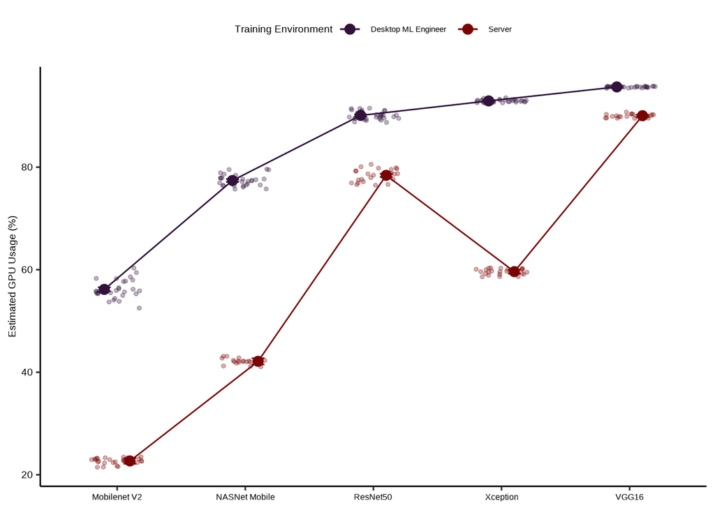

```r
# Set the desired order for the x axis
emm_gpu_df$architecture <- factor(emm_gpu_df$architecture, levels = c("Mobilenet V2", "NASNet Mobile", "ResNet50", "Xception", "VGG16"))

ggplot() +
  # Raw data jittered
  geom_jitter(
    data = filtered_gpu_data,
    aes(x = architecture, y = gpu_usage, color = training_environment),
    width = 0.2, alpha = 0.3, size = 1
  ) +
  # Estimated points
  geom_point(
    data = emm_gpu_df,
    aes(x = architecture, y = gpu_estimate, color = training_environment, group = training_environment),
    size = 3, position = position_dodge(width = 0.4)
  ) +
  # Line connecting the points
  geom_line(
    data = emm_gpu_df,
    aes(x = architecture, y = gpu_estimate, color = training_environment, group = training_environment),
    position = position_dodge(width = 0.4)
  ) +
  # Error bars
  geom_errorbar(
    data = emm_gpu_df,
    aes(x = architecture, ymin = lower_CI, ymax = upper_CI, color = training_environment, group = training_environment),
    width = 0.2, position = position_dodge(width = 0.4)
  ) +
  labs(
    title = NULL,
    x = NULL,
    y = "Estimated GPU Usage (%)",
    color = "Training Environment"
  ) +
  theme_pubr() +
  theme(
    text = element_text(size = 14),
    axis.text.x = element_text(size = 12)
  )
```

## Visualize estimated energy consumption and gpu usage by architecture and training environment

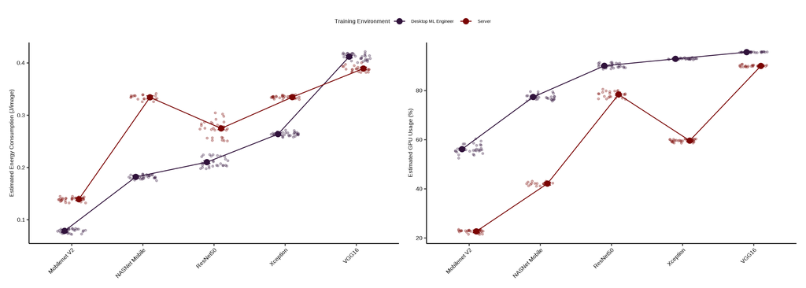

```r
energy_plot <- ggplot() +
  geom_jitter(
    data = filtered_energy_data,
    aes(x = architecture, y = energy, color = training_environment),
    width = 0.2, alpha = 0.3, size = 1
  ) +
  geom_point(
    data = emm_df,
    aes(x = architecture, y = energy_estimate, color = training_environment, group = training_environment),
    size = 3, position = position_dodge(width = 0.4)
  ) +
  geom_line(
    data = emm_df,
    aes(x = architecture, y = energy_estimate, color = training_environment, group = training_environment),
    position = position_dodge(width = 0.4)
  ) +
  geom_errorbar(
    data = emm_df,
    aes(x = architecture, ymin = lower_CI, ymax = upper_CI, color = training_environment, group = training_environment),
    width = 0.2, position = position_dodge(width = 0.4)
  ) +
  labs(
    title = NULL,
    x = NULL,
    y = "Estimated Energy Consumption (J/image)",
    color = "Training Environment"
  ) +
  theme_pubr() +
  theme(
    text = element_text(size = 14),
    axis.text.x = element_text(angle = 45, hjust = 1)
  )
# Create the GPU usage plot
gpu_plot <- ggplot() +
  geom_jitter(
    data = filtered_gpu_data,
    aes(x = architecture, y = gpu_usage, color = training_environment),
    width = 0.2, alpha = 0.3, size = 1
  ) +
  geom_point(
    data = emm_gpu_df,
    aes(x = architecture, y = gpu_estimate, color = training_environment, group = training_environment),
    size = 3, position = position_dodge(width = 0.4)
  ) +
  geom_line(
    data = emm_gpu_df,
    aes(x = architecture, y = gpu_estimate, color = training_environment, group = training_environment),
    position = position_dodge(width = 0.4)
  ) +
  geom_errorbar(
    data = emm_gpu_df,
    aes(x = architecture, ymin = lower_CI, ymax = upper_CI, color = training_environment, group = training_environment),
    width = 0.2, position = position_dodge(width = 0.4)
  ) +
  labs(
    title = NULL,
    x = NULL,
    y = "Estimated GPU Usage (%)",
    color = "Training Environment"
  ) +
  theme_pubr() +
  theme(
    text = element_text(size = 14),
    axis.text.x = element_text(angle = 45, hjust = 1)
  )
# grid.arrange(energy_plot, gpu_plot, ncol = 2)

(energy_plot | gpu_plot) +
  plot_layout(guides = "collect") &
  theme(legend.position = "top")
```